# Pre-Processamento Xco2

2024-09-05

# Carregando os pacotes e dependências necessárias

```r
library(tidyverse)
library(raster)
library(fco2r)
library(sp)
source("../R/minhas-funcoes.R")
source("../R/meu-tema.R")
source("../R/polis.R")
```

## Calculando o valor da SIF

```r
oco2_br <- fco2r::oco2_br %>%
  mutate(sif = (fluorescence_radiance_757nm_idp_ph_sec_1_m_2_sr_1_um_1*2.6250912*10^(-19)  + 1.5*fluorescence_radiance_771nm_idp_ph_sec_1_m_2_sr_1_um_1* 2.57743*10^(-19))/2) %>%
    mutate(
    xco2 = xco2_moles_mole_1*1e06,
    data = lubridate::ymd_hms(time_yyyymmddhhmmss),
    year = lubridate::year(data),
    month = lubridate::month(data),
    day = lubridate::day(data),
    day_month = case_when(
      year == 2015 ~ difftime(data,"2015-01-01", units = "days"),
      year == 2016 ~ difftime(data,"2016-01-01", units = "days"),
      year == 2017 ~ difftime(data,"2017-01-01", units = "days"),
      year == 2018 ~ difftime(data,"2018-01-01", units = "days"),
      year == 2019 ~ difftime(data,"2019-01-01", units = "days"),
      year == 2020 ~ difftime(data,"2020-01-01", units = "days"),
    ),
    day_week = lubridate::wday(data),
    month_year = lubridate::make_date(year, month, 1))
```

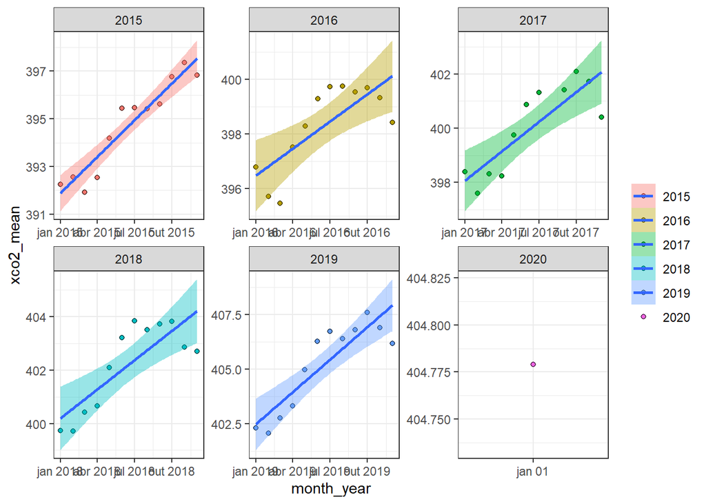

```r
oco2_br %>%
  filter(year %in% 2015:2020) %>%
  group_by(year, month_year) %>%
  summarise(xco2_mean = mean(xco2, na.rm =TRUE)) %>%
  ggplot(aes(x=month_year,y=xco2_mean,
                               fill=forcats::as_factor(year))) +
  geom_point(shape=21,color="black") +
  # geom_line(color="red") +
  geom_smooth(method = "lm") +
  facet_wrap(~year,scales = "free")+
  # ggpubr::stat_regline_equation(aes(
  #    label =  paste(..eq.label.., ..rr.label.., sep = "*plain(\",\")~~"))) +
  theme_bw() +
  labs(fill="")
```

Existe uma tendência de aumento monotônica mundial da concentração de CO<sub>2</sub> na atmosfera, assim, ela deve ser modelada para obtermos **β<sub>1</sub>** para ser considerado o padrão para comparação às tendências de uma determinada região. Devido à periodicidade de retorno do satélite em um ponto (ao redor de 16 dias) os dados devem ser agrupados pelo mês dentro de um determinado ano.

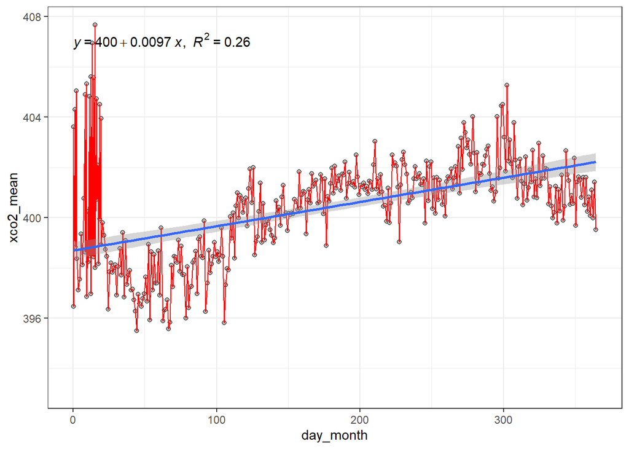

```r
oco2_br %>%
  filter(year %in% 2014:2020) %>%
  group_by(day_month) %>%
  summarise(xco2_mean = mean(xco2, na.rm =TRUE)) %>%
  ggplot(aes(x=day_month,y=xco2_mean )) +
  geom_point(shape=21,color="black",fill="gray") +
  geom_line(color="red") +
  geom_smooth(method = "lm") +
  ggpubr::stat_regline_equation(aes(
  label =  paste(..eq.label.., ..rr.label.., sep = "*plain(\",\")~~"))) +
  theme_bw()
```

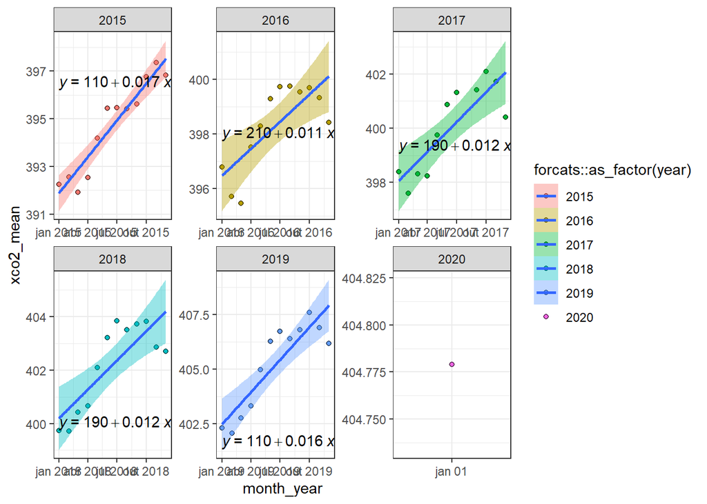

```r
oco2_br %>%
  filter(year %in% 2015:2020) %>%
  group_by(year, month_year) %>%
  summarise(xco2_mean = mean(xco2, na.rm =TRUE)) %>%
  ggplot(aes(x=month_year,y=xco2_mean,
                               fill=forcats::as_factor(year))) +
  geom_point(shape=21,color="black") +
  #geom_line(color="red") +
  geom_smooth(method = "lm") +
  facet_wrap(~year,scales = "free")+
  ggpubr::stat_regline_equation(aes(
  label =  paste(..eq.label.., ..rr.label.., sep = "*plain(\",\")~~"))) +
  theme_bw()
```

A próxima operação é selecionar na base de dados somente os pontos pertencentes ao território brasileiro. Assim vamos utilizar o pacote `{geobr}` para criarmos os filtros a partir dos polígonos das diferentes regiões do Brasil.

```r
regiao <- geobr::read_region(showProgress = FALSE)
br <- geobr::read_country(showProgress = FALSE)
```

Agora podemos extrair os polígonos.

```r
### Polígono Brasil
pol_br <- br$geom %>% purrr::pluck(1) %>% as.matrix()
```

```r
### Polígonos das Regiões
pol_norte <- regiao$geom %>% purrr::pluck(1) %>% as.matrix()
pol_nordeste <- regiao$geom %>% purrr::pluck(2) %>% as.matrix()
pol_sudeste <- regiao$geom %>% purrr::pluck(3) %>% as.matrix()
pol_sul <- regiao$geom %>% purrr::pluck(4) %>% as.matrix()
pol_centroeste<- regiao$geom %>% purrr::pluck(5) %>% as.matrix()
```

```r
# Retirando alguns pontos para correção
pol_br <- pol_br[pol_br[,1]<=-34,]
pol_br <- pol_br[!((pol_br[,1]>=-38.8 & pol_br[,1]<=-38.6) &
                              (pol_br[,2]>= -19 & pol_br[,2]<= -16)),]

# Arrumando alguns pontos
pol_nordeste <- pol_nordeste[pol_nordeste[,1]<=-34,]
pol_nordeste <- pol_nordeste[!((pol_nordeste[,1]>=-38.7 & pol_nordeste[,1]<=-38.6) & pol_nordeste[,2]<= -15),]

# retirando pontos do sudeste
pol_sudeste <- pol_sudeste[pol_sudeste[,1]<=-30,]
```

Plot de todos os pontos.

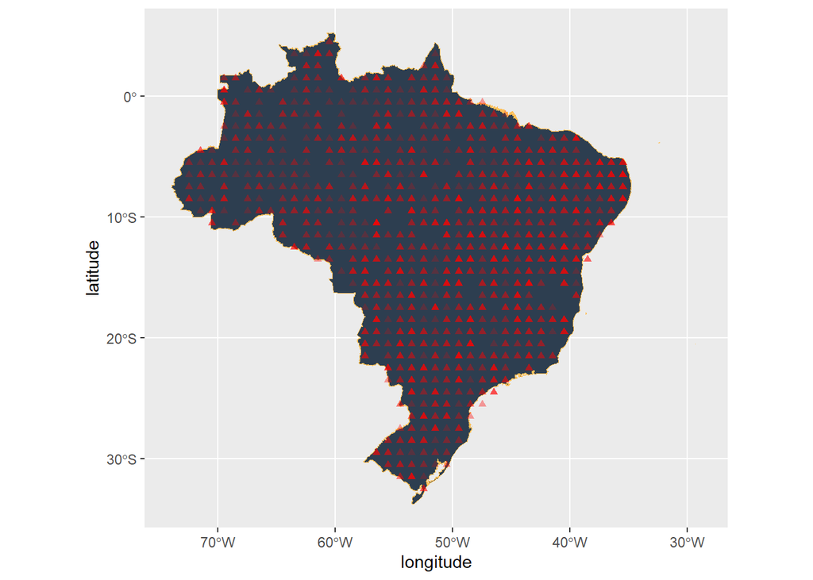

```r
 br %>%
   ggplot() +
   geom_sf(fill="#2D3E50", color="#FEBF57",
           size=.15, show.legend = FALSE) +
   geom_point(data=oco2_br %>% sample_n(2000),
              aes(x=longitude, y=latitude),
              shape=17,
              col="red",
              alpha=0.2)
```

```r
oco2_br <- oco2_br %>%
          mutate(
            flag_br = def_pol(longitude, latitude, pol_br),
            flag_norte = def_pol(longitude, latitude, pol_norte),
            flag_nordeste = def_pol(longitude, latitude, pol_nordeste),
            flag_sul = def_pol(longitude, latitude, pol_sul),
            flag_sudeste = def_pol(longitude, latitude, pol_sudeste),
            flag_centroeste = def_pol(longitude, latitude, pol_centroeste)
          )
```

Verificação dos pontos dentro do território brasileiro.

```r
 br %>%
   ggplot() +
   geom_sf(fill="#2D3E50", color="#FEBF57",
           size=.15, show.legend = FALSE) +
   geom_point(data=oco2_br %>%
                         filter(flag_norte |
                                         flag_sul |
                                         flag_sudeste|
                                         flag_centroeste|
                                         flag_nordeste) %>%
                         sample_n(20000) %>%
                         filter(year == 2014) ,
              aes(x=longitude, y=latitude),
              shape=17,
              col="red",
              alpha=0.2)
```

[output not shown]

Pra garantir a reprodutibilidade desse material, vamos salvar/disponibilizar os dados na base `oco2_br_trend.rds`, somente com os pontos dentro do território nacional.

```r
  readr::write_rds(oco2_br %>%
                     filter(flag_norte |
                                         flag_sul |
                                         flag_sudeste|
                                         flag_centroeste|
                                         flag_nordeste),
                     "../data/oco2_br_trend.rds")
```

Vamos ler o banco de dados *[com a tendência]*.

```r
oco2_br_trend <- readr::read_rds("../data/oco2_br_trend.rds")
```

Devemos criar a análise para um ano específico, pois a comparação do artigo será ano a ano.

```r
oco2_nest <- oco2_br_trend %>%
  filter(year == 2015) %>%
  tibble::as_tibble() %>%
  mutate(quarter = lubridate::quarter(data),
                quarter_year = lubridate::make_date(year, quarter, 1)) %>%   pivot_longer(
    starts_with("flag"),
    names_to = "region",
    values_to = "flag",
  ) %>%
  filter(flag) %>%
  mutate(region = stringr::str_remove(region,"flag_")) %>%
  group_by(region, longitude, latitude, month_year) %>%
  summarise(xco2_mean = mean(xco2, na.rm=TRUE)) %>%
  mutate(
    regi = region,
    id_time = month_year
  ) %>%
  group_by(region, latitude, longitude) %>%
  nest()
```

Função para construção da análise de regressão linear para cada pixel, e diagnósticos.

```r
linear_reg <- function(df, output="beta1"){
  # Modelo para cada pixel
  modelo <- lm(xco2_mean ~ month_year, data=df)
  beta_1 <- c(summary(modelo)$coefficients[2])

  # Definindo o modelo
  if(output=="beta1"){
    return(beta_1)
  }

  # Salvando o valor P
  if(output=="p_value"){
    if(is.nan(beta_1)){
      beta_1 <- 0
      p <- 1
    }else{
      p <- summary(modelo)$coefficients[2,4]
      if(is.nan(p)) p <- 1
    }
    return(p)
  }

  # Criando gráfico
  if(output=="plot"){
    plot <- df %>%
      ggplot(aes(x=dia,y=xco2_mean)) +
      geom_point() +
      theme_bw()
    return(plot)
  }
  if(output=="hist"){
    hist <- df %>%
      ggplot(aes(x=xco2_mean, y=..density..)) +
      geom_histogram(bins=10, color="black", fill="lightgray") +
      geom_density()+
      theme_bw()
    return(hist)
  }

  # Anomalia é o Xco2 do regional menos o Xco2 do pixel, melhor é o contrário.
  if(output == "partial"){
     partial <- df %>%
       summarise(xco2 = mean(xco2_mean), na.mr=TRUE) %>%
       pull(xco2)
     return(partial)
  }

    if(output == "n"){
     return(nrow(df))
   }
}
```

Vamos aplicar a função para cada ponto de amostragem do satélite (pixel).

```r
oco2_nest <- oco2_nest %>%
  mutate(
    beta_line = purrr::map(data,linear_reg, output="beta1"),
    p_value = purrr::map(data,linear_reg, output="p_value"),
    partial = purrr::map(data,linear_reg, output="partial"),
    n_obs = purrr::map(data,linear_reg, output="n")
    #plot = purrr::map(data,linear_reg, output="plot"),
    #hist = purrr::map(data,linear_reg, output="hist")
  )
oco2_nest$data[[1]]
```

```
## # A tibble: 3 × 4
##   month_year xco2_mean regi  id_time
##   <date>         <dbl> <chr> <date>
## 1 2015-07-01      400. br    2015-07-01
## 2 2015-09-01      398. br    2015-09-01
## 3 2015-11-01      399. br    2015-11-01
```

```r
# oco2_nest %>%
#   filter(region == "norte") %>%
#   filter(p_value < 0.05, beta_line < 0) %>%
#   pull(plot)
```

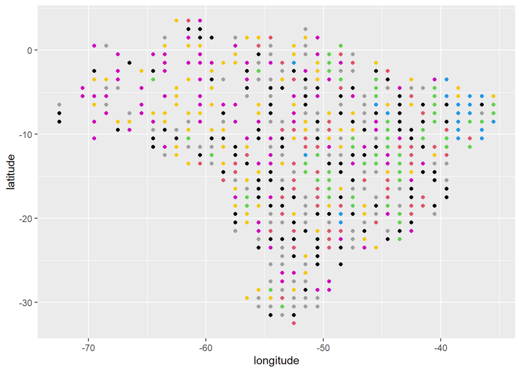

```r
oco2_nest %>%
  # filter(p_value < 0.05) %>%
  filter(n_obs > 5) %>%
  # mutate(class = ifelse(beta_line > limite_inferior_beta_regional,
  #                              1,ifelse(beta_line < limite_inferior_beta_regional, -1, 0))
  #               ) %>%
  dplyr::select(longitude, latitude, n_obs) %>%
  ggplot(aes(x=longitude, y=latitude, color = n_obs)) +
  geom_point()
```

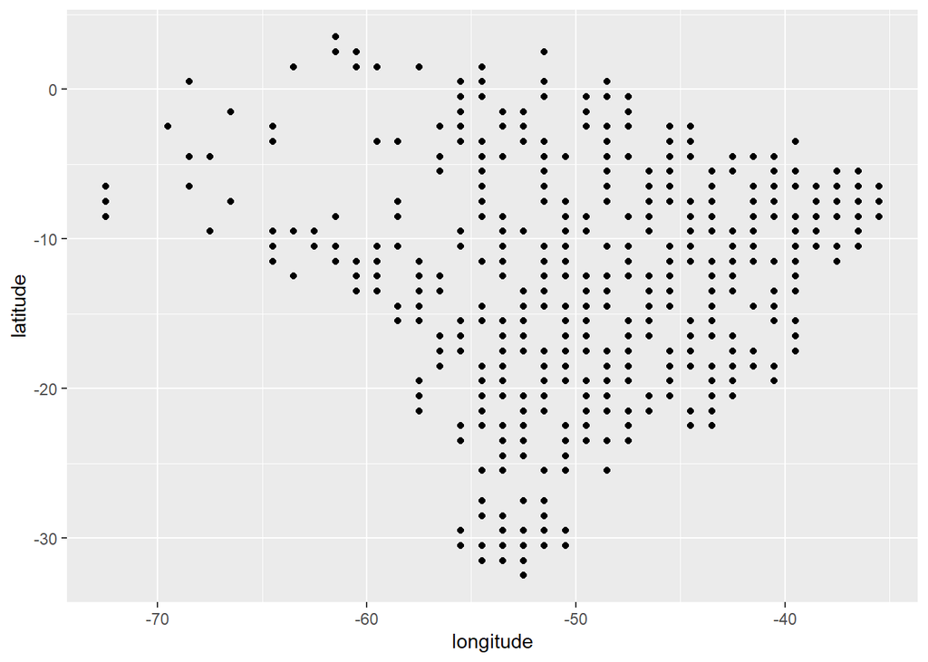

```r
oco2_aux <- oco2_nest %>%
  filter(n_obs > 7) %>%
  unnest(cols = c(beta_line, partial)) %>%
  ungroup() %>%
  dplyr::select(longitude, latitude, beta_line, partial)

q3_oco2 <- oco2_aux %>% pull(beta_line) %>% quantile(.75)

oco2_aux <- oco2_aux %>%
  mutate(
    anomaly =  partial - oco2_aux %>%
      pull(partial) %>%
      mean(),
    Dbeta = beta_line - oco2_aux %>%
      pull(beta_line) %>% mean(na.rm=TRUE)
  )
q3_anom <- oco2_aux %>% pull(anomaly) %>% quantile(.75)


oco2_aux <- oco2_aux %>%
  mutate(
    beta_index =  ifelse(beta_line <=q3_oco2, 0, 1)
  )

# Mapeando
oco2_aux %>%
  ggplot(aes(x=longitude, y=latitude) ) +
  geom_point()
```

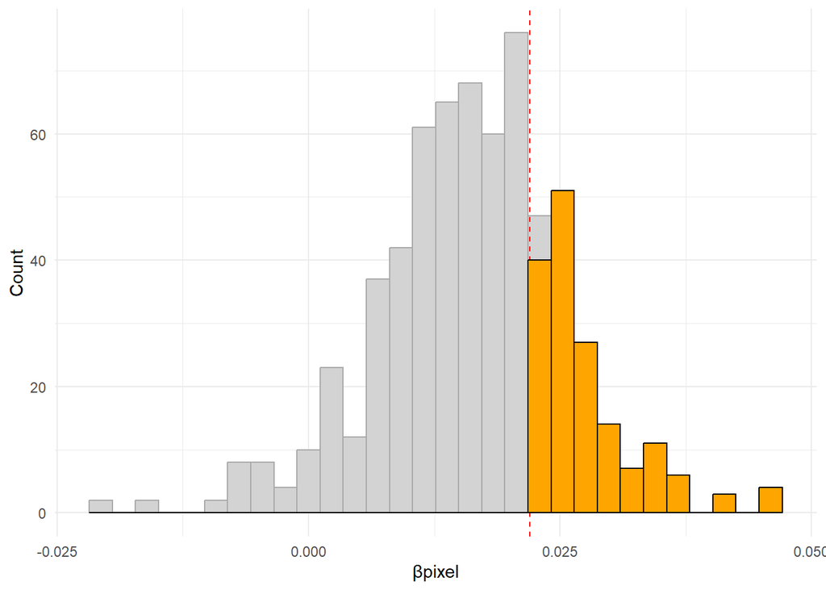

```r
oco2_aux %>%
  ggplot(aes(x=beta_line)) +
  geom_histogram(bins=30,
                          fill="orange",
                          color="black") +
  labs(x="βpixel",y="Count") +
  geom_vline(xintercept = q3_oco2,
                      color = "red",
                      lty=2) +
  gghighlight::gghighlight(beta_line > q3_oco2,
                           unhighlighted_params = list(
                               color = "darkgray",
                               fill = "lightgray")) +
  theme_minimal()
```

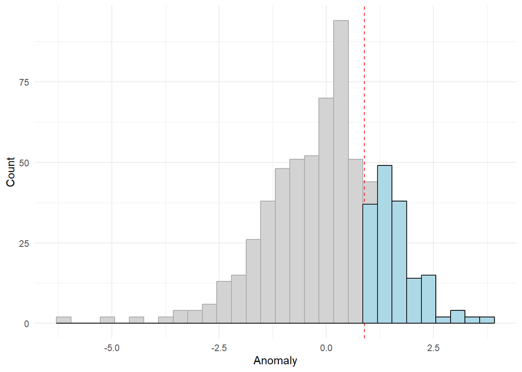

```r
oco2_aux %>%
  ggplot(aes(x=anomaly)) +
  geom_histogram(bins=30,
                          fill="lightblue",
                          color="black") +
  labs(x="Anomaly",y="Count") +
  geom_vline(xintercept = q3_anom,
                      color = "red",
                      lty=2) +
  gghighlight::gghighlight(anomaly > q3_anom,
                           unhighlighted_params = list(
                               color = "darkgray",
                               fill = "lightgray")) +
  theme_minimal()
```

```r
oco2_aux <- oco2_aux %>%
  group_by(longitude,latitude) %>%
  summarise(
    beta_line = mean(beta_line),
    partial = mean(partial),
    anomaly = mean(anomaly),
    Dbeta = mean(Dbeta),
    beta_index = mean(beta_index)
  ) %>% ungroup()
sp::coordinates(oco2_aux)=~ longitude+latitude
form_beta<-beta_line~1
form_anom<-anomaly~1
form_index<-beta_index~1
```

### Semivariograma para beta

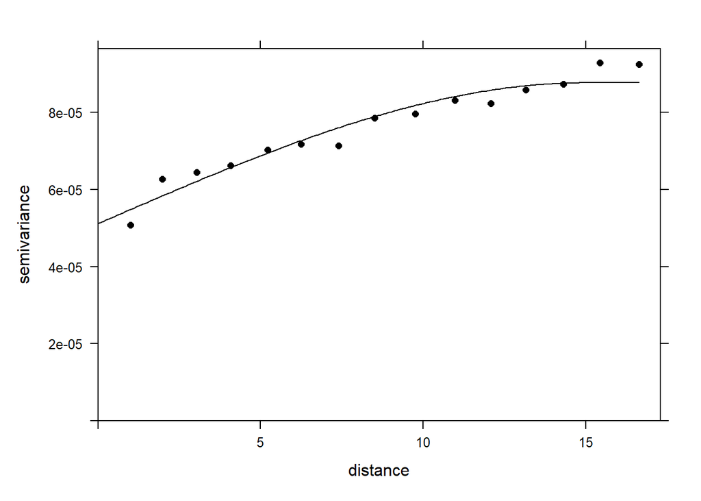

```r
vari_beta <- gstat::variogram(form_beta, data=oco2_aux)
m_beta <- gstat::fit.variogram(vari_beta,fit.method = 7,
                               gstat::vgm(1, "Sph", 8, 1))
plot(vari_beta,model=m_beta, col=1,pl=F,pch=16)
```

### Semivariograma para anomalia

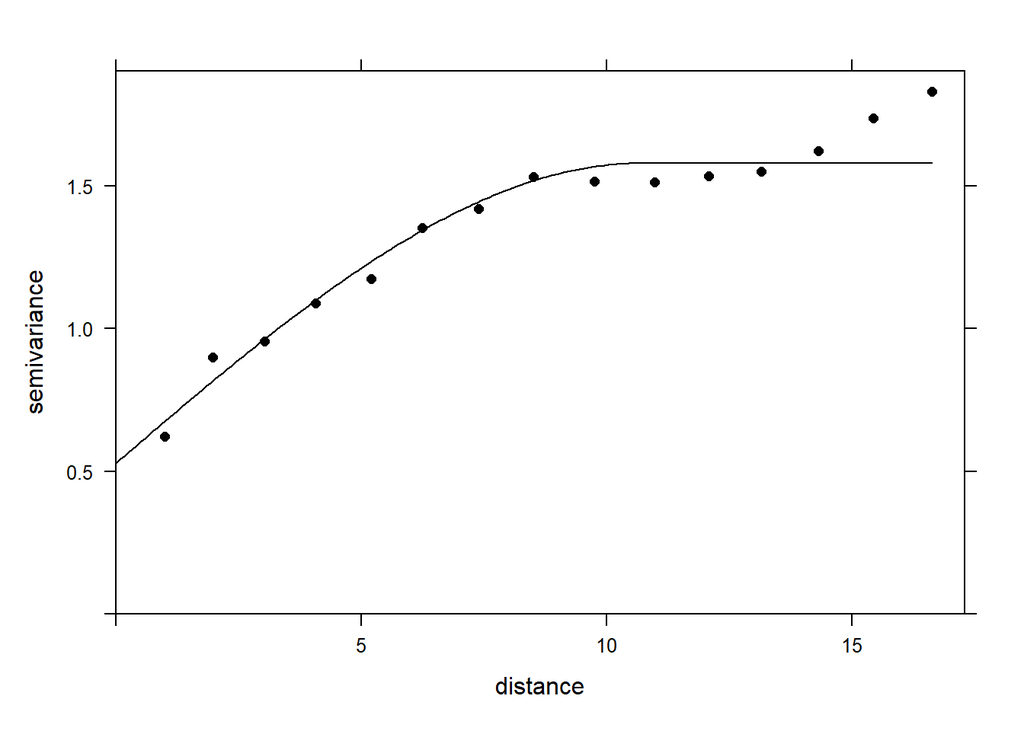

```r
vari_anom<-gstat::variogram(form_anom, data=oco2_aux)
m_anom <- gstat::fit.variogram(vari_anom,gstat::vgm(.8,"Sph",9,.2))
plot(vari_anom, model=m_anom, col=1,pl=F,pch=16)
```

### Semivariograma para beta_index

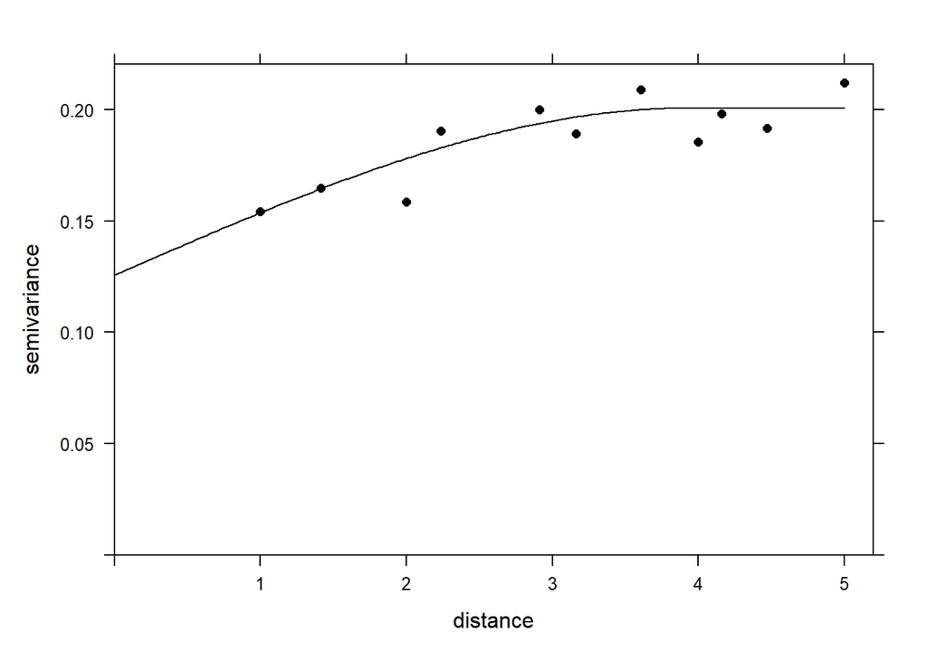

```r
vari_index <- gstat::variogram(form_index, data=oco2_aux,
                               cutoff = 5,
                               width = 5/15)
m_index <- gstat::fit.variogram(vari_index,fit.method = 7,
                               gstat::vgm(1, "Sph", 4, 1))
plot(vari_index,model=m_index, col=1,pl=F,pch=16)
```

```r
x<-oco2_aux$longitude
y<-oco2_aux$latitude
dis <- .1 #Distância entre pontos
grid <- expand.grid(X=seq(min(x),max(x),dis), Y=seq(min(y),max(y),dis))
sp::gridded(grid) = ~ X + Y
```

```r
ko_beta<-gstat::krige(formula=form_beta, oco2_aux, grid, model=m_beta,
    block=c(0,0),
    nsim=0,
    na.action=na.pass,
    debug.level=-1,
    )
```

```
## [using ordinary kriging]
##   5% done 14% done 24% done 33% done 43% done 52% done 62% done 71% done 81% done 90% done 99% done100% done
```

```r
ko_anom<-gstat::krige(formula=form_anom, oco2_aux, grid, model=m_anom,
    block=c(0,0),
    nsim=0,
    na.action=na.pass,
    debug.level=-1,
    )
```

```
## [using ordinary kriging]
##   7% done 16% done 25% done 34% done 44% done 53% done 62% done 72% done 81% done 90% done 99% done100% done
```

```r
ko_index<-gstat::krige(formula=form_index, oco2_aux, grid, model=m_index,
    block=c(0,0),
    nsim=0,
    na.action=na.pass,
    debug.level=-1,
    )
```

```
## [using ordinary kriging]
##   2% done 11% done 20% done 28% done 35% done 42% done 49% done 57% done 66% done 75% done 84% done 93% done100% done
```

```r
mapa <- geobr::read_state(showProgress = FALSE)
```

```r
get_pol_in_pol <- function(indice, lista, gradeado){
  poligono <- lista %>% purrr::pluck(indice) %>% as.matrix()
  flag <- def_pol(gradeado$X, gradeado$Y, poligono)
  return(flag)
}
flag <- purrr::map_dfc(1:27, get_pol_in_pol, lista=mapa$geom, gradeado = grid)
flag_br <- apply(flag, 1, sum) != 0
```

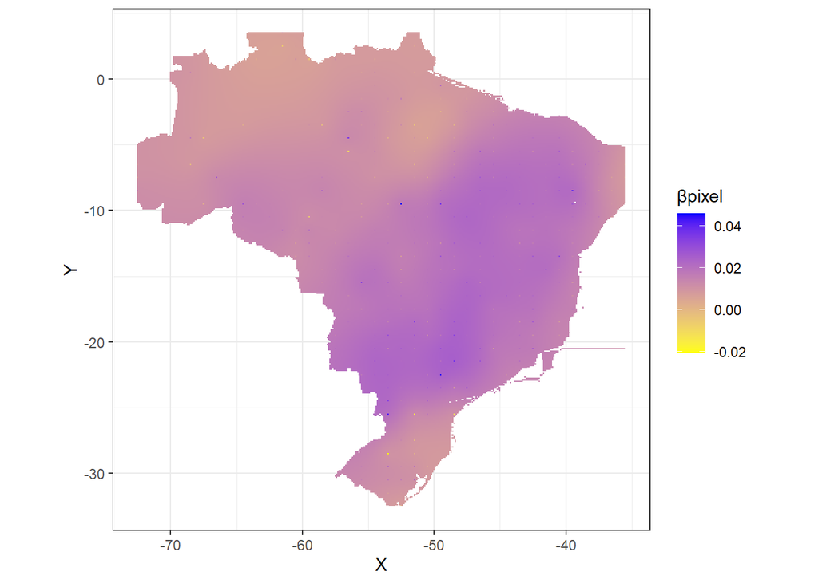

```r
tibble::as_tibble(ko_beta) %>%
  tibble::add_column(flag_br) %>%
  filter(flag_br) %>%
  ggplot(aes(x=X, y=Y),color="black") +
  geom_tile(aes(fill = var1.pred)) +
  scale_fill_gradient(low = "yellow", high = "blue") +
  coord_equal()+
  labs(fill="βpixel") +
  theme_bw()
```

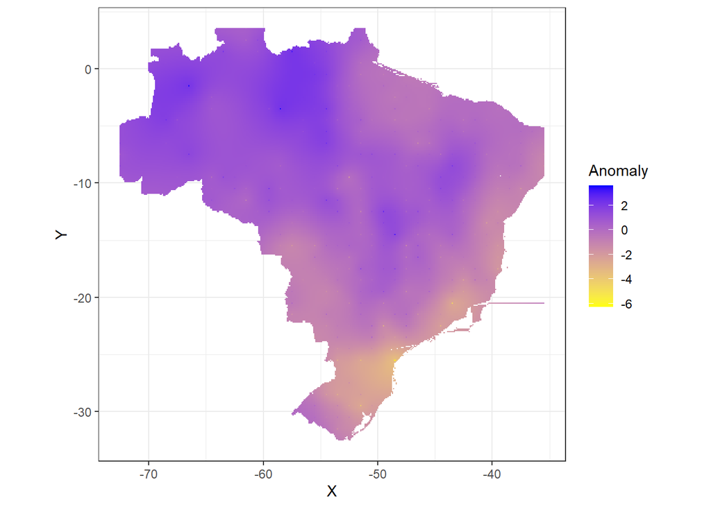

```r
tibble::as_tibble(ko_anom) %>%
  tibble::add_column(flag_br) %>%
  filter(flag_br) %>%
  ggplot(aes(x=X, y=Y),color="black") +
  geom_tile(aes(fill = var1.pred)) +
  scale_fill_gradient(low = "yellow", high = "blue") +
  coord_equal()+
  labs(fill="Anomaly") +
  theme_bw()
```

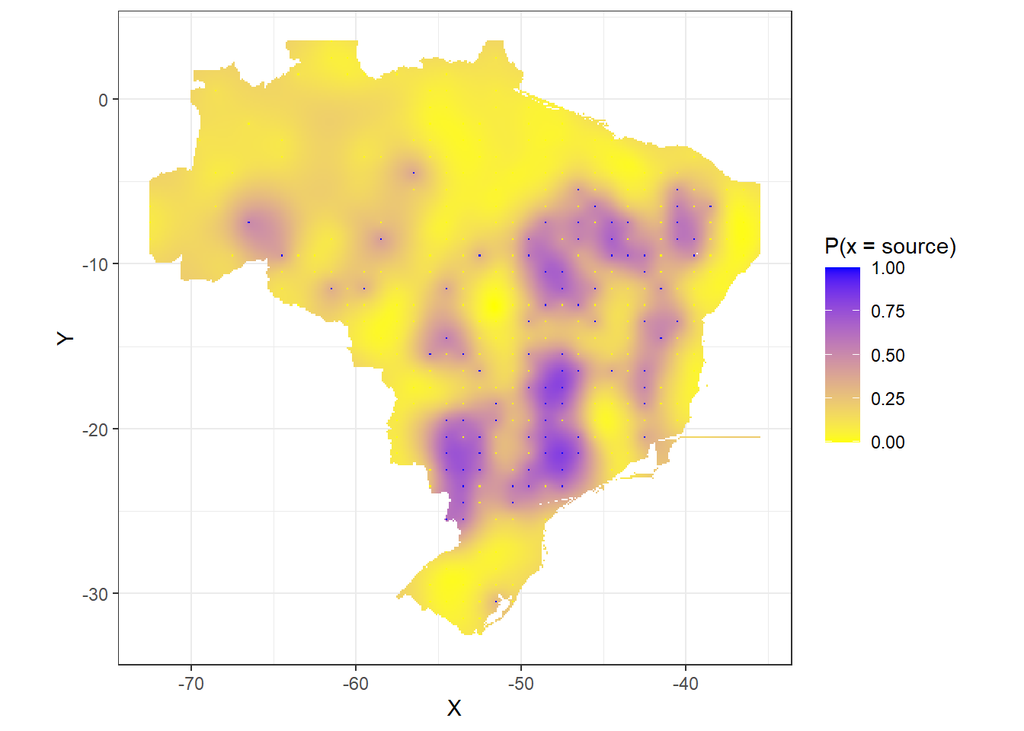

```r
tibble::as_tibble(ko_index) %>%
  tibble::add_column(flag_br) %>%
  filter(flag_br) %>%
  ggplot(aes(x=X, y=Y),color="black") +
  geom_tile(aes(fill = var1.pred)) +
  scale_fill_gradient(low = "yellow", high = "blue") +
  coord_equal()+
  labs(fill="P(x = source)") +
  theme_bw()
```

```r
# # Craindo as imagens # Criando o banco de dados
# oco2_br_trend <- oco2_br
# oco2_nest_total <- data.frame()
# for(ano in 2015:2019){
#  # Criando banco de dados aninhado por ano
#   oco2_nest <- oco2_br_trend %>%
#     filter(year == ano) %>%
#     mutate(
#       quarter = lubridate::quarter(data),
#       quarter_year = lubridate::make_date(year, quarter, 1)) %>%
#     pivot_longer(
#       cols = starts_with("flag"),
#       names_to = "region",
#       values_to = "flag",
#     ) %>%
#     filter(flag) %>%
#     mutate(region = stringr::str_remove(region,"flag_")) %>%
#     group_by(region, longitude, latitude, month_year) %>%
#     summarise(xco2_mean = mean(xco2, na.rm=TRUE)) %>%
#     mutate(
#       regi = region,
#       id_time = month_year
#     ) %>%
#     group_by(region, latitude, longitude) %>%
#     nest()
#
#   # Adicionando as colunas da regressão linear
#   oco2_nest <- oco2_nest %>%
#     mutate(
#       beta_line = purrr::map(data,linear_reg, output="beta1"),
#       p_value = purrr::map(data,linear_reg, output="p_value"),
#       partial = purrr::map(data,linear_reg, output="partial"),
#       n_obs = purrr::map(data,linear_reg, output="n")
#       #plot = purrr::map(data,linear_reg, output="plot"),
#       #hist = purrr::map(data,linear_reg, output="hist")
#     )
#   oco2_nest$ano <- ano
#   oco2_nest <- oco2_nest %>% relocate(ano)
#
#   if( ano == 2015){
#     oco2_nest_total <-  oco2_nest
#   } else {
#     oco2_nest_total <- rbind(oco2_nest_total, oco2_nest)
#   }
# }
# readr::write_rds(oco2_nest_total,"../data-raw/oco2_betanom.rds")
# oco2_betanom <- readr::read_rds("../data-raw/oco2_betanom.rds")
```

```r
# for( ano in 2015:2019){
# # Filtrando os pontos com n > 7
#   oco2_aux <- oco2_betanom %>%
#     filter(ano == ano) %>%
#     filter(n_obs > 7) %>%
#     unnest(cols = c(beta_line, partial)) %>%
#     ungroup() %>%
#     dplyr::select(region, longitude, latitude, beta_line, partial)
#
#   q3_oco2 <- oco2_aux %>% pull(beta_line) %>% quantile(.75)
#   oco2_aux <- oco2_aux %>%
#     mutate(
#       anomaly =  partial - oco2_aux %>%
#         pull(partial) %>%
#         mean(),
#       Dbeta = beta_line - oco2_aux %>%
#         pull(beta_line) %>% mean(na.rm=TRUE)
#     )
#   q3_anom <- oco2_aux %>% pull(anomaly) %>% quantile(.75)
#   oco2_aux <- oco2_aux %>%
#     mutate(
#       beta_index =  ifelse(beta_line <=q3_oco2, 0, 1)
#     )
#
#     # Craindo os gráficos
#   histograma_beta <- oco2_aux %>%
#     ggplot(aes(x=beta_line)) +
#     geom_histogram(bins=30,
#                             fill="orange",
#                             color="black") +
#     labs(x="βpixel",y="Count") +
#     geom_vline(xintercept = q3_oco2,
#                         color = "red",
#                         lty=2) +
#     gghighlight::gghighlight(n=2, beta_line > q3_oco2,
#                              unhighlighted_params = list(
#                                color = "darkgray",
#                                fill = "lightgray")) +
#     theme_minimal()
#
#   png(paste0("../img/histograma_beta_",ano,".png"))
#   print(histograma_beta)
#   dev.off()
#
#   histograma_anomaly <- oco2_aux %>%
#     ggplot(aes(x=anomaly)) +
#     geom_histogram(bins=30,
#                             fill="lightblue",
#                             color="black") +
#     labs(x="Anomaly",y="Count") +
#     geom_vline(xintercept = q3_anom,
#                         color = "red",
#                         lty=2) +
#     gghighlight::gghighlight(anomaly > q3_anom,
#                              unhighlighted_params = list(
#                                color = "darkgray",
#                                fill = "lightgray")) +
#     theme_minimal()
#
#   png(paste0("../img/histograma_anomaly_",ano,".png"))
#   print(histograma_anomaly)
#   dev.off()
# }
```